# Manhood & Masculinity

Jude Sullivan

2022-05-05

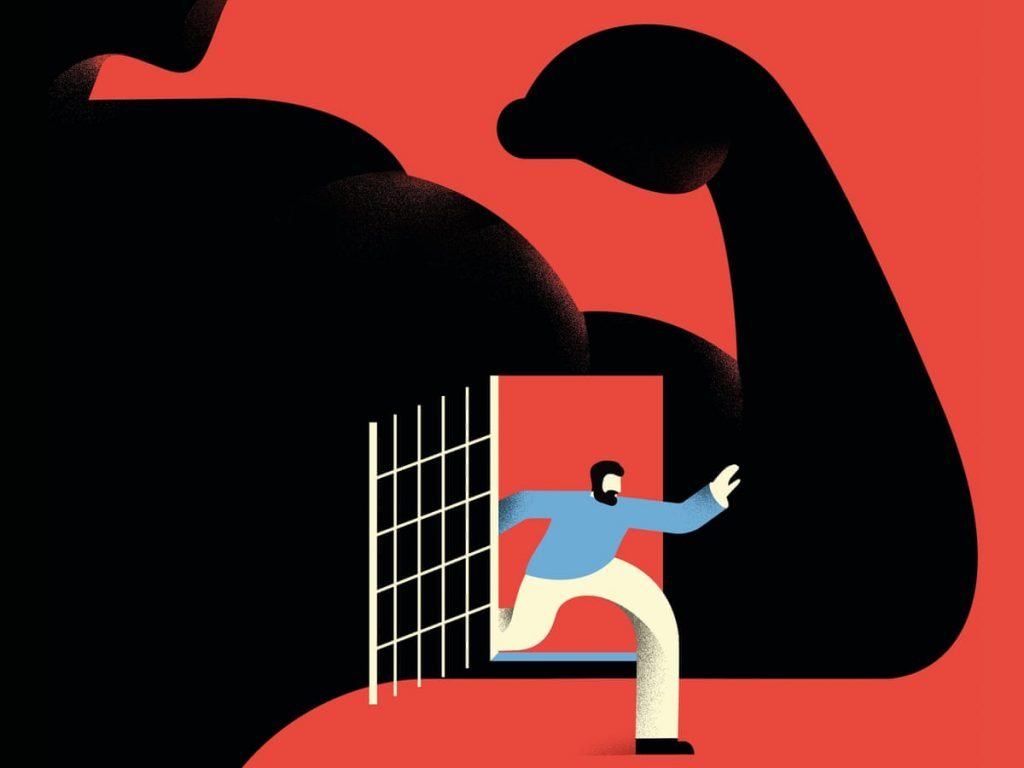

# Precarious Manhood

The precarious manhood hypothesis reflects the universal belief that manhood is a turbulent status that is hard to gain and easy to lose, and requires constant demonstration of masculinity in social environments (Gilmore, 1990; Vandello et al., 2008). This hypothesis is informed by principles of evolutionary psychology and Eagly’s (1987) social role theory. Beliefs about the typical roles of groups correspond with stereotypes of members from these groups on the fundamental dimensions of agency and communion (Koenig & Eagly, 2014). Consequently, men of color who occupy job positions that do not fit the social role expectations of their group (e.g., an Asian man who is a landscaper instead of a doctor) may face greater backlash from their position due to a perceived deviation from norms. In relation to the precarious manhood hypothesis, these men who deviate from social expectations might exhibit higher endorsement of manhood’s precarity due to the stereotypes challenges that they face as a result of their status. Here, the Asian man might feel that his manhood status is always questioned when he is criticized for his low-status occupation rather than attending medical school and trying to be more successful in life, which would suggest a perceived lack of agency. Research regarding the precarious manhood hypothesis has tested its relationship with aggression, financial risk-taking behavior, and unemployment metaperceptions in men, indicating real-world examples of how the precarity of manhood affects the daily lives of men (Michniewicz et al., 2014; Weaver et al., 2010; Weaver et al., 2013). While efforts have been made to explore the cross-cultural significance and overall generalizability of precarious manhood, less is known about the extent to which diverse groups endorse the idea that manhood is a status that has to be proven, especially if they already deviate from prototypical figures in a country.

In my honors thesis, I predicted that diverse men with two non-dominant identities (i.e., non-heterosexual men of color) would differ from individuals who only share one (i.e., non-heterosexual White men and heterosexual men of color) or none (i.e., heterosexual White men) of the same identities on their precarious manhood belief ratings. Per the sampled figure below, this hypothesis was not supported. Although the interaction effect was non-significant, non-White heterosexual men displayed the highest endorsement of precarious manhood beliefs (M = 4.57) while non-White non-heterosexual men displayed the lowest endorsement (M = 4.16) compared to respective White men, *F*(1, 747) = 0.80, p = 0.37.

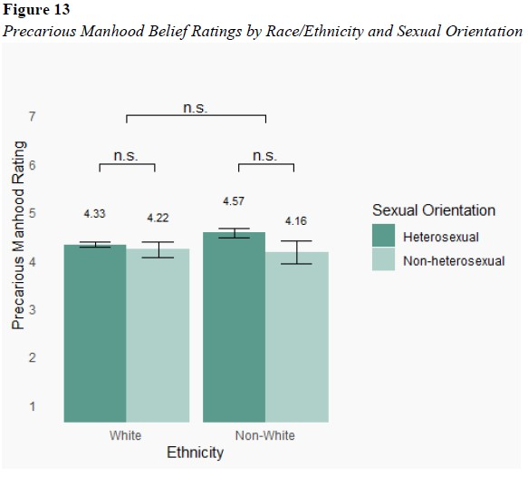

Interestingly, participant’s country of origin did not emerge as a covariate across my analyses, so I never compared precarious manhood belief ratings within or between men from Australia, Canada, England, Ireland, and the United States. The present work aims to fill in this gap in my previous research by investigating ratings within the United States specifically.

# Objectives

1. Examine the frequency of responses by country
2. Investigate Precarious Manhood Belief ratings within the United States

## Setting Up

```r
# Load packages

library(tidyverse)
library(dplyr)
library(knitr)
library(ggforce)
library(readr)
library(moments)
library(car)
library(ggsignif)
```

```r
# Import data file

manhood_dat <- read_csv("data/honorsthesis_clean.csv")
```

### Objective 1

```r
# 1 = Australia; 2 = Canada; 3 = England; 4 = Ireland; 5 = USA

partcoun_fre <- manhood_dat |>
  group_by(partcoun) |>
  dplyr::summarize(n = n()) |>
  mutate(fre = (n / sum(n) * 100) |>  round(2))

kable(partcoun_fre)
```

| partcoun | n | fre |
| --- | --- | --- |
| 1 | 209 | 24.25 |
| 2 | 147 | 17.05 |
| 3 | 88 | 10.21 |
| 4 | 230 | 26.68 |
| 5 | 188 | 21.81 |

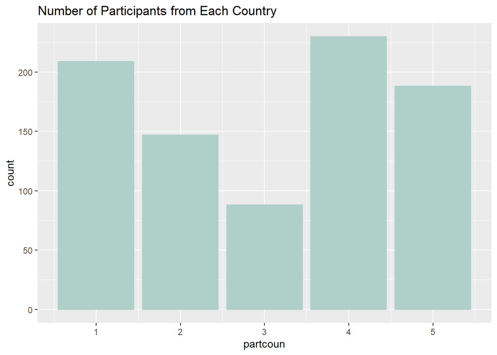

```r
# bar graph showing the number of participants from each country

ggplot(data = manhood_dat) +
  aes(partcoun) +
  geom_bar(color = "#afd0c9",
           fill = "#afd0c9") +
  labs(title = "Number of Participants from Each Country")
```

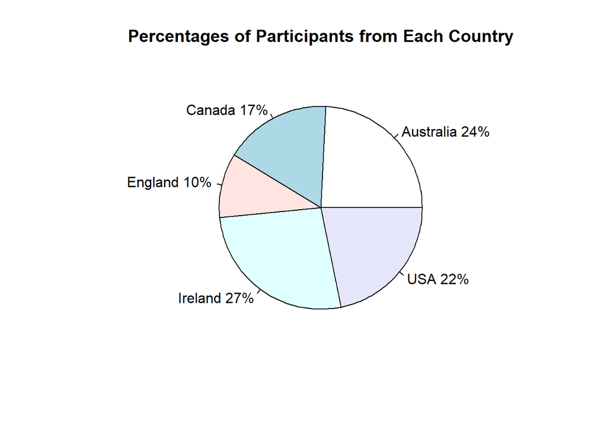

```r
# pie chart showing the percentage of participants from each country

count <- c(209, 147, 88, 230, 188)
countries <- c("Australia", "Canada", "England", "Ireland", "USA")
percent <- round(count/sum(count)*100)
countries <- paste(countries, percent)
countries <- paste(countries, "%", sep = "")
pie(count, labels = countries, main = "Percentages of Participants from Each Country")
```

### Objective 2

```r
# Descriptives for PMB ratings across all participants
# Scale:  1 = strongly disagree; 7 = strongly agree

preman <- manhood_dat |>
  dplyr::summarize_at(vars(preman_1, preman_2, preman_3, preman_4),
                      list(mean = mean, med = median, standde = sd, min = min, max = max,
                           skew = skewness, kur = kurtosis), na.rm = TRUE)

preman
```

```
## # A tibble: 1 × 28
##   preman_1_mean preman_2_mean preman_3_mean preman_4_mean preman_1_med
##           <dbl>         <dbl>         <dbl>         <dbl>        <dbl>
## 1          3.88          4.60          4.97          4.00            4
## # … with 23 more variables: preman_2_med <dbl>, preman_3_med <dbl>,
## #   preman_4_med <dbl>, preman_1_standde <dbl>, preman_2_standde <dbl>,
## #   preman_3_standde <dbl>, preman_4_standde <dbl>, preman_1_min <dbl>,
## #   preman_2_min <dbl>, preman_3_min <dbl>, preman_4_min <dbl>,
## #   preman_1_max <dbl>, preman_2_max <dbl>, preman_3_max <dbl>,
## #   preman_4_max <dbl>, preman_1_skew <dbl>, preman_2_skew <dbl>,
## #   preman_3_skew <dbl>, preman_4_skew <dbl>, preman_1_kur <dbl>, …
```

```r
# USA PMB ANOVA

preman_USA <- manhood_dat |>
  filter(partcoun == "5") |>
  dplyr::select(eth_di, sexor_di, preman) |>
  mutate(eth_di = factor(eth_di, labels = c("White", "Non-White"))) |>
  mutate(sexor_di = factor(sexor_di, labels = c("Heterosexual", "Non-heterosexual"))) |>
  drop_na() |>
  group_by(eth_di, sexor_di)


preman_USA_anova <- aov(preman ~ eth_di*sexor_di, data = preman_USA)

preman_USA_anova_table <- Anova(preman_USA_anova, type = 3)

preman_USA_anova_table
```

```
## Anova Table (Type III tests)
##
## Response: preman
##                  Sum Sq  Df  F value Pr(>F)
## (Intercept)     1011.17   1 476.0849 <2e-16 ***
## eth_di             2.80   1   1.3160 0.2531
## sexor_di           2.06   1   0.9690 0.3265
## eth_di:sexor_di    0.43   1   0.2031 0.6529
## Residuals        320.71 151
## ---
## Signif. codes:  0 '***' 0.001 '**' 0.01 '*' 0.05 '.' 0.1 ' ' 1
```

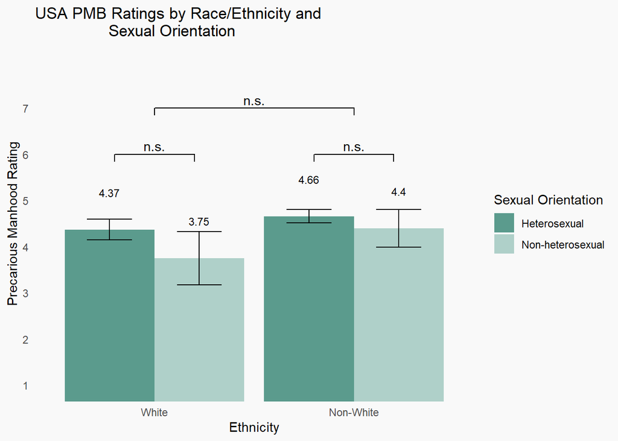

```r
# USA PMB Plot

preman_USA |>
  ggplot(aes(y = preman, x = eth_di, fill = sexor_di)) +
  stat_summary(geom = "bar", fun = mean, position = "dodge", width = 0.9) +
  stat_summary(geom = "errorbar", fun.data = mean_se, position = position_dodge(0.9),
               aes(width = 0.45)) +
  stat_summary(aes(label = round(..y.., 2)), fun = mean, geom = "text", size = 3, vjust = -4,
               position = position_dodge(0.9)) +
  geom_signif(y_position = c(6, 6), xmin = c(0.8, 1.8), xmax = c(1.2, 2.2),
              annotation = c("n.s.", "n.s."), tip_length = 0.025) +
  geom_signif(y_position = 7, xmin = c(1), xmax = c(2), annotation = c("n.s."),
              tip_length = 0.025) +
  scale_x_discrete("Ethnicity") +
  scale_y_continuous("Precarious Manhood Rating", breaks = seq(1, 7, 1)) +
  scale_fill_manual("Sexual Orientation", values = c("#5b9b8d", "#afd0c9")) +
  coord_cartesian(ylim = c(1, 8)) +
  theme_minimal() +
  theme(panel.grid.major = element_blank(), panel.grid.minor = element_blank(),
        plot.background = element_rect(fill = "#f9f9f9", color = "#f9f9f9"),
        panel.background = element_rect(fill = "#f9f9f9", color = "#f9f9f9")) +
  labs(title = "USA PMB Ratings by Race/Ethnicity and
                Sexual Orientation")
```

# Conclusion

This exploratory expansion upon precarious manhood belief ratings in the United States provided novel insights into how diverse men in the US might differ in their experiences with manhood and masculinity compared to their counterparts from other countries.

Contrary to my original results that included participants from five English-speaking countries, non-heterosexual White men in the United States had the lowest precarious manhood belief ratings in the present project, while heterosexual men of color still had the highest ratings. Additionally, the ANOVA table demonstrates how there was not a significant main effect of race/ethnicity or sexual orientation on precarious manhood belief ratings or an interaction effect.

Moving forward, it would be very interesting to investigate this finding even further. What exactly about the United States leads to such different experiences between White and non-White non-heterosexual men? Do non-heterosexual men of color in other countries face less backlash for having two non-dominant identities? Is the present result simply attributed to different racial/ethnic compositions between countries (e.g., are more non-heterosexual men of color identifying as Black in the United States compared to non-heterosexual men in Australia, Canada, England, and Ireland)? Nuanced findings like these are not placed at the forefront of research on gender or even of masculinity, but these differences can have very real implications for how diverse men live their lives around the world and for how they interact with others.

# Resources

- Eagly, A. H. (1987). *Sex Differences in Social Behavior: A Social-role interpretation* (1st ed.). Psychology Press. https://doi.org/10.4324/9780203781906
- https://cutacut.com/2020/11/19/heres-how-toxic-masculinity-is-restrictive-for-men/
- Gilmore, D. D. (1990). *Manhood in the making: Cultural concepts of masculinity.* Yale University Press.
- Koenig, A. M., & Eagly, A. H. (2014). Evidence for the social role theory of stereotype content: Observations of groups’ roles shape stereotypes. *Journal of Personality and Social Psychology, 107*(3), 371–392. https://doi-org.ezproxy.lib.usf.edu/10.1037/a0037215
- Michniewicz, K. S., Vandello, J. A., & Bosson, J. K. (2014). Men’s (Mis)Perceptions of the Gender Threatening Consequences of Unemployment. *Sex Roles, 3*(4), 88. doi: 10.1007/s11199-013-0339-3
- Vandello, J. A., Bosson, J. K., Cohen, D., Burnaford, R., & Weaver, J. (2008). Precarious manhood. *Journal of Personality and Social Psychology, 95,* 1325–1339. doi:10.1037/a0012453
- Weaver, J. R., Vandello, J. A., & Bosson, J. K. (2013). Intrepid, imprudent, or impetuous? The effects of gender threats on men’s financial decisions. *Psychology of Men & Masculinity, 14*(2), 184–191. doi:10.1037/a0027087
- Weaver, J. R., Vandello, J. A., Bosson, J. K., & Burnaford, R. M.(2010). The Proof is in the Punch: Gender Differences in Perceptions of Action and Aggression as Components of Manhood. *Sex Roles, 62*(3–4), 241–251. doi: 10.1007/s11199-009-9713-6